# Practical Machine learning - Course project

Diwakar Sharma

January 30, 2016

# Section I : Introduction

## Motivation

This project requires us to predict the **manner** in which an activity was performed based on the values of measurements received from activity tracking devices. This is to be done by using machine learning algorithms that once trained on *labeled* data can then **predict** the activity based on specific measurements.

## Data used

While the data has been sourced from the Coursera website, the true source is from [Human Activity Recognition](http://groupware.les.inf.puc-rio.br/har) for the **Weight Lifting Exercises Dataset**. The data consists of 19622 observations, each having a series of measurement values as well as the actual *manner* in which the exercise was being done. This was used as the model *training* data. Apart from this data there is another *testing* dataset which has 20 observations where the developed models are to be applied for prediction.

## Summary of analysis approach

The analysis was conducted in 3 major blocks :

1. Setup modeling data
   - import data
   - setup test and train datasets
2. Variable treatment
   - create dummy variables
   - remove non varying variables
   - delete variable with missing values
3. Model development
   - develop sub-models using different ML techniques (Random forest, K nearest neighbour & Neural Net)
   - combine these sub-models into one overall model

The overall model was then used to score the test data and results submitted for evaluation

# Section II : Analysis details

## Step 1 : Setup modelling data

### 1.1 Read in data

The data is provided in csv files, with one file for train and test datasets. The files are read into R while ensuring that :

- strings are not converted to factors
- any “#DIV/0!”, “NA” values are converted to missing numerical data
- column lables are read in from the first row
- the outcome variable (**classe**) present in the training dataset is converted into a factor

```r
training <- read.table("pml-training.csv", header = TRUE, sep = ",", stringsAsFactors = FALSE, row.names = 1, na.strings = c("#DIV/0!","NA"))
testing <- read.table("pml-testing.csv", header = TRUE, sep = ",", stringsAsFactors = FALSE, row.names = 1, na.strings = c("#DIV/0!","NA"))
training$classe <- as.factor(training$classe)
```

### 1.2 Remove un-required columns

The data contains certain character columns which are not required for model prediction purposes. These columns need to be deleted form the datasets

```r
var_list <- sapply(training, class)
table(var_list)
```

```
## var_list
## character    factor   integer   logical   numeric
##         3         1        34         6       115
```

```r
which(var_list == "character")
```

```
##      user_name cvtd_timestamp     new_window
##              1              4              5
```

```r
training <- training[,-c(1,4)]
testing <- testing[,-c(1,4)]
```

## Step 2 : Variable treatment

### 2.1 Convert character variables to dummy variables

The ML techniques being tested are not able to work on character variables. There is one character variable in the data “*new_window*”. This variable is therefore converted into binary dummy variables, where each unique value of the original variable translates into one binary dummy.

```r
for (level in unique(training$new_window)) {
        training[paste("new_window", level, sep = ".")] <- ifelse(training$new_window == level, 1, 0)
        testing[paste("new_window", level, sep = ".")] <- ifelse(testing$new_window == level, 1, 0)
}
which(sapply(training, class) == "character")
```

```
## new_window
##          3
```

```r
training <- training[,-3]
testing <- testing[,-3]
```

### 2.2 Remove non varying variables

Any variable which is a constant i.e. has only 1 unique value is removed from the analysis.

```r
var_non_varying <- which(sapply(training, function(x) length(unique(x))) <= 1)
var_non_varying
```

```
##     kurtosis_yaw_belt     skewness_yaw_belt kurtosis_yaw_dumbbell
##                    10                    13                    85
## skewness_yaw_dumbbell  kurtosis_yaw_forearm  skewness_yaw_forearm
##                    88                   123                   126
```

```r
training <- subset(training, select = -c(var_non_varying))
testing <- subset(testing, select = -c(var_non_varying))
```

### 2.3 delete variable where non modal values are insignificant (200) in number

Any variable where the most occuring (modal) value constitutes the majority of the data is also removed.

```r
var_non_model_not_signficant <- which(sapply(training, function(x) {sum(table(x)) - max(table(x))}) <= 200)
var_non_model_not_signficant
```

```
##   amplitude_pitch_belt     amplitude_yaw_belt amplitude_yaw_dumbbell
##                     19                     20                     93
##  amplitude_yaw_forearm
##                    129
```

```r
training <- subset(training, select = -c(var_non_model_not_signficant))
testing <- subset(testing, select = -c(var_non_model_not_signficant))
```

### 2.4 delete variable with missing values

The ML techniques are not able to handel missing values, so any variables having missing values are removed as well.

```r
var_with_missing <- which(sapply(training, function(x) {sum(is.na(x))}) > 0)
var_with_missing
```

```
##       kurtosis_roll_belt      kurtosis_picth_belt       skewness_roll_belt
##                        8                        9                       10
##     skewness_roll_belt.1            max_roll_belt           max_picth_belt
##                       11                       12                       13
##             max_yaw_belt            min_roll_belt           min_pitch_belt
##                       14                       15                       16
##             min_yaw_belt      amplitude_roll_belt     var_total_accel_belt
##                       17                       18                       19
##            avg_roll_belt         stddev_roll_belt            var_roll_belt
##                       20                       21                       22
##           avg_pitch_belt        stddev_pitch_belt           var_pitch_belt
##                       23                       24                       25
##             avg_yaw_belt          stddev_yaw_belt             var_yaw_belt
##                       26                       27                       28
##            var_accel_arm             avg_roll_arm          stddev_roll_arm
##                       42                       43                       44
##             var_roll_arm            avg_pitch_arm         stddev_pitch_arm
##                       45                       46                       47
##            var_pitch_arm              avg_yaw_arm           stddev_yaw_arm
##                       48                       49                       50
##              var_yaw_arm        kurtosis_roll_arm       kurtosis_picth_arm
##                       51                       61                       62
##         kurtosis_yaw_arm        skewness_roll_arm       skewness_pitch_arm
##                       63                       64                       65
##         skewness_yaw_arm             max_roll_arm            max_picth_arm
##                       66                       67                       68
##              max_yaw_arm             min_roll_arm            min_pitch_arm
##                       69                       70                       71
##              min_yaw_arm       amplitude_roll_arm      amplitude_pitch_arm
##                       72                       73                       74
##        amplitude_yaw_arm   kurtosis_roll_dumbbell  kurtosis_picth_dumbbell
##                       75                       79                       80
##   skewness_roll_dumbbell  skewness_pitch_dumbbell        max_roll_dumbbell
##                       81                       82                       83
##       max_picth_dumbbell         max_yaw_dumbbell        min_roll_dumbbell
##                       84                       85                       86
##       min_pitch_dumbbell         min_yaw_dumbbell  amplitude_roll_dumbbell
##                       87                       88                       89
## amplitude_pitch_dumbbell       var_accel_dumbbell        avg_roll_dumbbell
##                       90                       92                       93
##     stddev_roll_dumbbell        var_roll_dumbbell       avg_pitch_dumbbell
##                       94                       95                       96
##    stddev_pitch_dumbbell       var_pitch_dumbbell         avg_yaw_dumbbell
##                       97                       98                       99
##      stddev_yaw_dumbbell         var_yaw_dumbbell    kurtosis_roll_forearm
##                      100                      101                      114
##   kurtosis_picth_forearm    skewness_roll_forearm   skewness_pitch_forearm
##                      115                      116                      117
##         max_roll_forearm        max_picth_forearm          max_yaw_forearm
##                      118                      119                      120
##         min_roll_forearm        min_pitch_forearm          min_yaw_forearm
##                      121                      122                      123
##   amplitude_roll_forearm  amplitude_pitch_forearm        var_accel_forearm
##                      124                      125                      127
##         avg_roll_forearm      stddev_roll_forearm         var_roll_forearm
##                      128                      129                      130
##        avg_pitch_forearm     stddev_pitch_forearm        var_pitch_forearm
##                      131                      132                      133
##          avg_yaw_forearm       stddev_yaw_forearm          var_yaw_forearm
##                      134                      135                      136
```

```r
training <- subset(training, select = -c(var_with_missing))
testing <- subset(testing, select = -c(var_with_missing))
```

### 2.5 remove non sensical variables

The remaining variables are listed out and any non-sensical variables are removed.

```r
names(testing)
```

```
##  [1] "raw_timestamp_part_1" "raw_timestamp_part_2" "num_window"
##  [4] "roll_belt"            "pitch_belt"           "yaw_belt"
##  [7] "total_accel_belt"     "gyros_belt_x"         "gyros_belt_y"
## [10] "gyros_belt_z"         "accel_belt_x"         "accel_belt_y"
## [13] "accel_belt_z"         "magnet_belt_x"        "magnet_belt_y"
## [16] "magnet_belt_z"        "roll_arm"             "pitch_arm"
## [19] "yaw_arm"              "total_accel_arm"      "gyros_arm_x"
## [22] "gyros_arm_y"          "gyros_arm_z"          "accel_arm_x"
## [25] "accel_arm_y"          "accel_arm_z"          "magnet_arm_x"
## [28] "magnet_arm_y"         "magnet_arm_z"         "roll_dumbbell"
## [31] "pitch_dumbbell"       "yaw_dumbbell"         "total_accel_dumbbell"
## [34] "gyros_dumbbell_x"     "gyros_dumbbell_y"     "gyros_dumbbell_z"
## [37] "accel_dumbbell_x"     "accel_dumbbell_y"     "accel_dumbbell_z"
## [40] "magnet_dumbbell_x"    "magnet_dumbbell_y"    "magnet_dumbbell_z"
## [43] "roll_forearm"         "pitch_forearm"        "yaw_forearm"
## [46] "total_accel_forearm"  "gyros_forearm_x"      "gyros_forearm_y"
## [49] "gyros_forearm_z"      "accel_forearm_x"      "accel_forearm_y"
## [52] "accel_forearm_z"      "magnet_forearm_x"     "magnet_forearm_y"
## [55] "magnet_forearm_z"     "problem_id"           "new_window.no"
## [58] "new_window.yes"
```

```r
testing <- testing[,-c(1,2)]
training <- training[,-c(1,2)]
```

## Step 3 : Model development

### 3.1 Build random forest model

The training data is passed through a Random Forest model. The model is built using :

- 8 variables to be tested for node split
- At least 200 records in each terminal node
- 600 trees in the forest
- The modeling would be done using the multicore capabilities of the system
- The resulting model’s confusion matrix is displayed to assess the predictive power

```r
forest_size <- 600
num_cluster <- 6
library(foreach)
library(doParallel)
library(caret)
library(randomForest)
cl <- makeCluster(num_cluster)
registerDoParallel(cl)
start.time <- proc.time()
set.seed(33833)
rf <- foreach(ntree = rep(round(forest_size/num_cluster,0), num_cluster), .combine = combine, .packages = 'randomForest', .multicombine = TRUE, .inorder = FALSE) %dopar%
{
        randomForest(subset(training, select = -c(classe)), training[,"classe"], ntree = ntree, mtry = 8, nodesize = 200, do.trace = FALSE, importance = FALSE)
}
elapsed.time <- proc.time() - start.time
stopCluster(cl)
rf
```

```
##
## Call:
##  randomForest(x = subset(training, select = -c(classe)), y = training[,      "classe"], ntree = ntree, mtry = 8, nodesize = 200, importance = FALSE,      do.trace = FALSE)
##                Type of random forest: classification
##                      Number of trees: 600
## No. of variables tried at each split: 8
```

```r
print(paste("Random Forest build done - time taken =")); print(elapsed.time)
```

```
## [1] "Random Forest build done - time taken ="
```

```
##    user  system elapsed
##    0.34    0.33   20.66
```

```r
rf.pred.train <- predict(rf, training)
rf.pred.test <- predict(rf, testing)
rf.confusionmatrix <- confusionMatrix(rf.pred.train, training$classe)
rf.confusionmatrix
```

```
## Confusion Matrix and Statistics
##
##           Reference
## Prediction    A    B    C    D    E
##          A 5535  156    0    1    0
##          B   21 3457  180    7   20
##          C   12  176 3232  248   54
##          D    9    8   10 2945   53
##          E    3    0    0   15 3480
##
## Overall Statistics
##
##                Accuracy : 0.9504
##                  95% CI : (0.9473, 0.9534)
##     No Information Rate : 0.2844
##     P-Value [Acc > NIR] : < 2.2e-16
##
##                   Kappa : 0.9372
##  Mcnemar's Test P-Value : < 2.2e-16
##
## Statistics by Class:
##
##                      Class: A Class: B Class: C Class: D Class: E
## Sensitivity            0.9919   0.9105   0.9445   0.9157   0.9648
## Specificity            0.9888   0.9856   0.9698   0.9951   0.9989
## Pos Pred Value         0.9724   0.9381   0.8684   0.9736   0.9949
## Neg Pred Value         0.9968   0.9787   0.9881   0.9837   0.9921
## Prevalence             0.2844   0.1935   0.1744   0.1639   0.1838
## Detection Rate         0.2821   0.1762   0.1647   0.1501   0.1774
## Detection Prevalence   0.2901   0.1878   0.1897   0.1542   0.1783
## Balanced Accuracy      0.9904   0.9480   0.9571   0.9554   0.9818
```

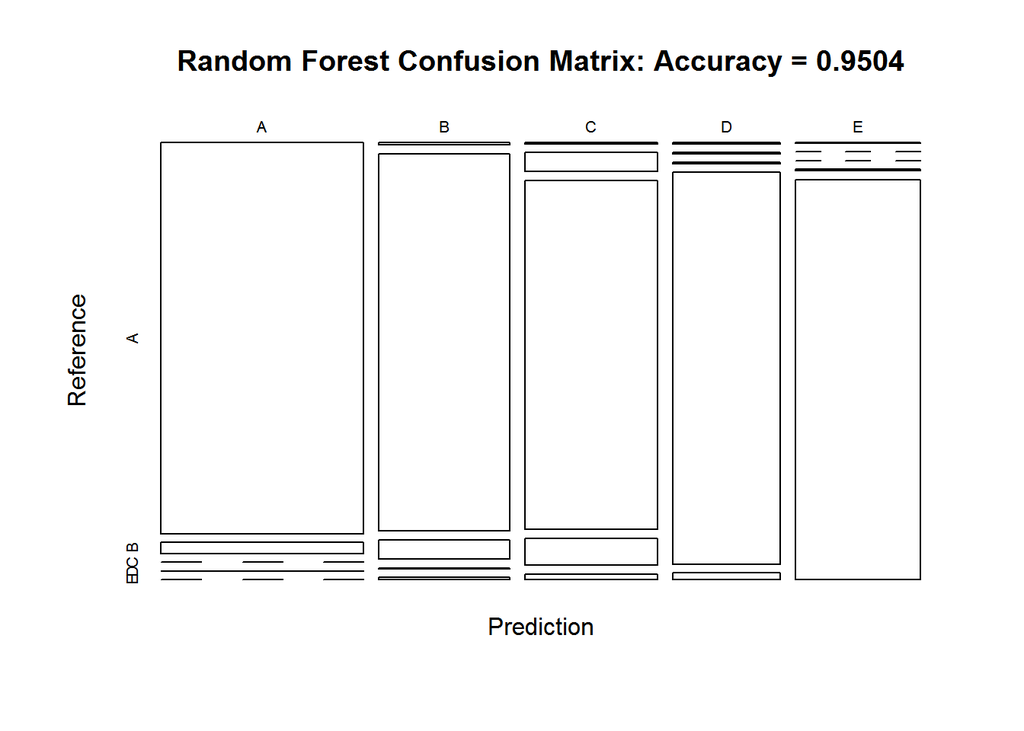

```r
plot(
        rf.confusionmatrix$table,
        col = rf.confusionmatrix$byClass,
        main = paste("Random Forest Confusion Matrix: Accuracy =", round(rf.confusionmatrix$overall['Accuracy'], 4))
        )
```

### 3.2 Build K nearest neighbour

The training data is passed through a K nearest neighbour model. The model is built using :

- 5 fold cross validation to identify the best value of k (number of neighbours considered)
- The modeling would be done using the multicore capabilities of the system
- The resulting model’s confusion matrix is displayed to assess the predictive power

```r
cl <- makeCluster(num_cluster)
registerDoParallel(cl)
start.time <- proc.time()
set.seed(33833)
knn <- train(
        x = subset(training, select = -c(classe)),
        y = training[,"classe"],
        method = "knn",
        trControl = trainControl(method = "cv", number = 5),
        preProcess = c("center","scale"),
        tuneGrid = data.frame(.k = 6:7)
        )
elapsed.time <- proc.time() - start.time
stopCluster(cl)
knn
```

```
## k-Nearest Neighbors
##
## 19622 samples
##    55 predictor
##     5 classes: 'A', 'B', 'C', 'D', 'E'
##
## Pre-processing: centered, scaled
## Resampling: Cross-Validated (5 fold)
## Summary of sample sizes: 15698, 15699, 15697, 15697, 15697
## Resampling results across tuning parameters:
##
##   k  Accuracy   Kappa      Accuracy SD  Kappa SD
##   6  0.9555601  0.9437798  0.004782418  0.006050799
##   7  0.9528590  0.9403533  0.004442923  0.005630249
##
## Accuracy was used to select the optimal model using  the largest value.
## The final value used for the model was k = 6.
```

```r
print(paste("KNN build done - time taken =")); print(elapsed.time)
```

```
## [1] "KNN build done - time taken ="
```

```
##    user  system elapsed
##    1.33    0.27   57.73
```

```r
knn.pred.train <- predict(knn, subset(training, select = -c(classe)))
knn.pred.test <- predict(knn, testing[,-54])
knn.confusionmatrix <- confusionMatrix(knn.pred.train, training$classe)
knn.confusionmatrix
```

```
## Confusion Matrix and Statistics
##
##           Reference
## Prediction    A    B    C    D    E
##          A 5543   55    6    6    5
##          B   11 3674   19    5   11
##          C   13   54 3368   69   15
##          D   11   10   26 3129   18
##          E    2    4    3    7 3558
##
## Overall Statistics
##
##                Accuracy : 0.9822
##                  95% CI : (0.9802, 0.984)
##     No Information Rate : 0.2844
##     P-Value [Acc > NIR] : < 2.2e-16
##
##                   Kappa : 0.9774
##  Mcnemar's Test P-Value : 9.755e-15
##
## Statistics by Class:
##
##                      Class: A Class: B Class: C Class: D Class: E
## Sensitivity            0.9934   0.9676   0.9842   0.9729   0.9864
## Specificity            0.9949   0.9971   0.9907   0.9960   0.9990
## Pos Pred Value         0.9872   0.9876   0.9571   0.9796   0.9955
## Neg Pred Value         0.9974   0.9923   0.9966   0.9947   0.9969
## Prevalence             0.2844   0.1935   0.1744   0.1639   0.1838
## Detection Rate         0.2825   0.1872   0.1716   0.1595   0.1813
## Detection Prevalence   0.2862   0.1896   0.1793   0.1628   0.1821
## Balanced Accuracy      0.9941   0.9823   0.9874   0.9845   0.9927
```

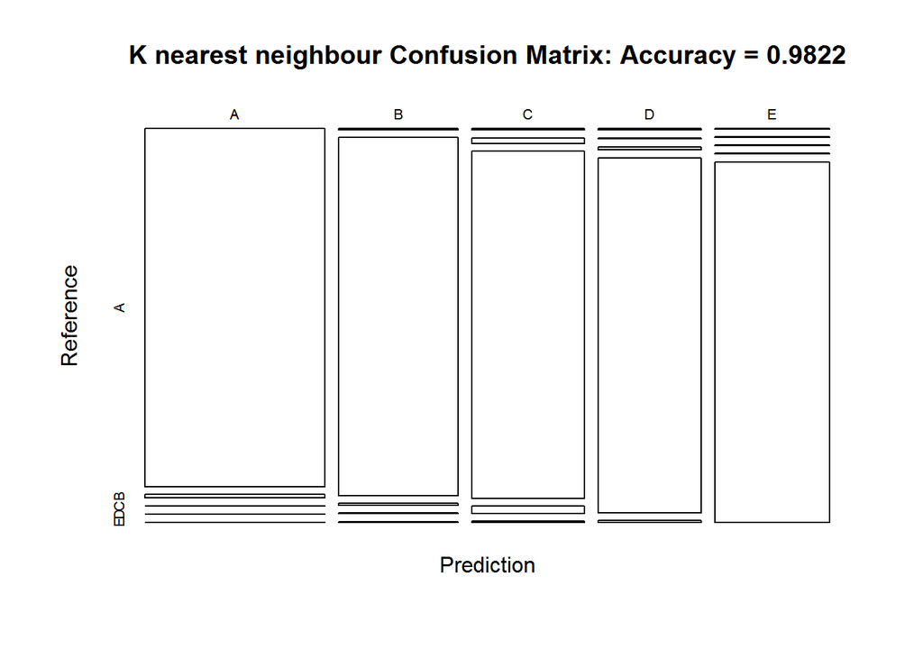

```r
plot(
        knn.confusionmatrix$table,
        col = knn.confusionmatrix$byClass,
        main = paste("K nearest neighbour Confusion Matrix: Accuracy =", round(knn.confusionmatrix$overall['Accuracy'], 4))
)
```

### 3.3 Build Neural Net model

The training data is passed through a Neural Net model. The model is built using :

- 5 fold cross validation to be done to identify the optimal number of hidden nodes (size)
- The modeling would be done using the multicore capabilities of the system
- The resulting model’s confusion matrix is displayed to assess the predictive power

```r
cl <- makeCluster(num_cluster)
registerDoParallel(cl)
start.time <- proc.time()
set.seed(33833)
nnetGrid <- expand.grid(.size = 15:17, .decay = 0)
nnet <- train(classe ~ .,
                 data = training,
                 method = "nnet",
                 preProc = c("center", "scale", "spatialSign"),
                 tuneGrid = nnetGrid,
                 trace = FALSE,
                 trControl = trainControl(method = "cv", number = 5, classProbs = TRUE))
stopCluster(cl)
nnet
```

```
## Neural Network
##
## 19622 samples
##    55 predictor
##     5 classes: 'A', 'B', 'C', 'D', 'E'
##
## Pre-processing: centered, scaled, spatial sign transformation
## Resampling: Cross-Validated (5 fold)
## Summary of sample sizes: 15698, 15699, 15697, 15697, 15697
## Resampling results across tuning parameters:
##
##   size  Accuracy   Kappa      Accuracy SD  Kappa SD
##   15    0.9120877  0.8887735  0.007253784  0.009170575
##   16    0.9275299  0.9083157  0.004258632  0.005359534
##   17          NaN        NaN           NA           NA
##
## Tuning parameter 'decay' was held constant at a value of 0
## Accuracy was used to select the optimal model using  the largest value.
## The final values used for the model were size = 16 and decay = 0.
```

```r
elapsed.time <- proc.time() - start.time
print(paste("Neural net build done - time taken =")); print(elapsed.time)
```

```
## [1] "Neural net build done - time taken ="
```

```
##    user  system elapsed
##   24.26    0.34  107.30
```

```r
nnet.pred.train <- predict(nnet, training)
nnet.pred.test <- predict(nnet, testing)
nnet.confusionmatrix <- confusionMatrix(nnet.pred.train, training$classe)
nnet.confusionmatrix
```

```
## Confusion Matrix and Statistics
##
##           Reference
## Prediction    A    B    C    D    E
##          A 5418  101    3   25    5
##          B   92 3570  125   27   25
##          C    4   62 3158  171   52
##          D   56   31   82 2953   44
##          E   10   33   54   40 3481
##
## Overall Statistics
##
##                Accuracy : 0.9469
##                  95% CI : (0.9437, 0.95)
##     No Information Rate : 0.2844
##     P-Value [Acc > NIR] : < 2.2e-16
##
##                   Kappa : 0.9328
##  Mcnemar's Test P-Value : 9.711e-11
##
## Statistics by Class:
##
##                      Class: A Class: B Class: C Class: D Class: E
## Sensitivity            0.9710   0.9402   0.9229   0.9182   0.9651
## Specificity            0.9905   0.9830   0.9822   0.9870   0.9914
## Pos Pred Value         0.9759   0.9299   0.9162   0.9327   0.9621
## Neg Pred Value         0.9885   0.9856   0.9837   0.9840   0.9921
## Prevalence             0.2844   0.1935   0.1744   0.1639   0.1838
## Detection Rate         0.2761   0.1819   0.1609   0.1505   0.1774
## Detection Prevalence   0.2829   0.1956   0.1757   0.1613   0.1844
## Balanced Accuracy      0.9807   0.9616   0.9525   0.9526   0.9783
```

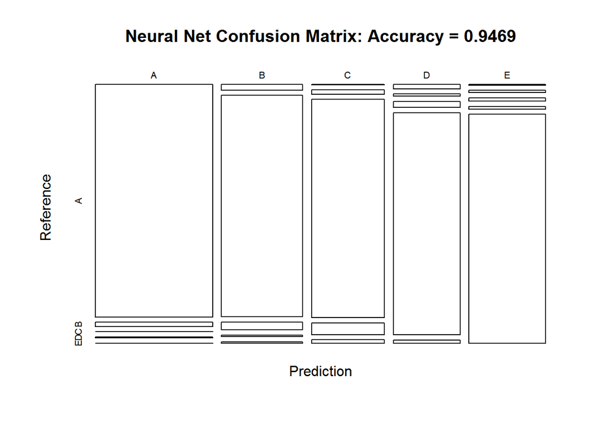

```r
plot(
        nnet.confusionmatrix$table,
        col = nnet.confusionmatrix$byClass,
        main = paste("Neural Net Confusion Matrix: Accuracy =", round(nnet.confusionmatrix$overall['Accuracy'], 4))
)
```

### 3.4 Combine models

The three developed models are put together using a random forest construct

```r
library(foreach)
library(doParallel)
library(randomForest)
cl <- makeCluster(num_cluster)
registerDoParallel(cl)
x <- data.frame(rf = rf.pred.train, knn = knn.pred.train, nnet = nnet.pred.train)
x.testing <- data.frame(rf = rf.pred.test, knn = knn.pred.test, nnet = nnet.pred.test)
y <- training$classe
start.time <- proc.time()
set.seed(33833)
combined <- foreach(ntree = rep(round(forest_size/num_cluster,0), num_cluster), .combine = combine, .packages = 'randomForest', .multicombine = TRUE, .inorder = FALSE) %dopar%
{
        randomForest(x, y, ntree = ntree, mtry = 3, nodesize = 200, do.trace = FALSE, importance = FALSE)
}
elapsed.time <- proc.time() - start.time
stopCluster(cl)
combined
```

```
##
## Call:
##  randomForest(x = x, y = y, ntree = ntree, mtry = 3, nodesize = 200,      importance = FALSE, do.trace = FALSE)
##                Type of random forest: classification
##                      Number of trees: 600
## No. of variables tried at each split: 3
```

```r
print(paste("Combined build done - time taken =")); print(elapsed.time)
```

```
## [1] "Combined build done - time taken ="
```

```
##    user  system elapsed
##    0.15    0.09    1.20
```

```r
combined.pred.train <- predict(combined, x)
combined.pred.test <- predict(combined, x.testing)
combined.confusionmatrix <- confusionMatrix(combined.pred.train, training$classe)
combined.confusionmatrix
```

```
## Confusion Matrix and Statistics
##
##           Reference
## Prediction    A    B    C    D    E
##          A 5545   55    6    6    5
##          B   11 3674   19    4    0
##          C    0   53 3359   51    2
##          D   24   11   35 3147   31
##          E    0    4    3    8 3569
##
## Overall Statistics
##
##                Accuracy : 0.9833
##                  95% CI : (0.9814, 0.985)
##     No Information Rate : 0.2844
##     P-Value [Acc > NIR] : < 2.2e-16
##
##                   Kappa : 0.9789
##  Mcnemar's Test P-Value : 3.101e-15
##
## Statistics by Class:
##
##                      Class: A Class: B Class: C Class: D Class: E
## Sensitivity            0.9937   0.9676   0.9816   0.9785   0.9895
## Specificity            0.9949   0.9979   0.9935   0.9938   0.9991
## Pos Pred Value         0.9872   0.9908   0.9694   0.9689   0.9958
## Neg Pred Value         0.9975   0.9923   0.9961   0.9958   0.9976
## Prevalence             0.2844   0.1935   0.1744   0.1639   0.1838
## Detection Rate         0.2826   0.1872   0.1712   0.1604   0.1819
## Detection Prevalence   0.2863   0.1890   0.1766   0.1655   0.1827
## Balanced Accuracy      0.9943   0.9827   0.9875   0.9862   0.9943
```

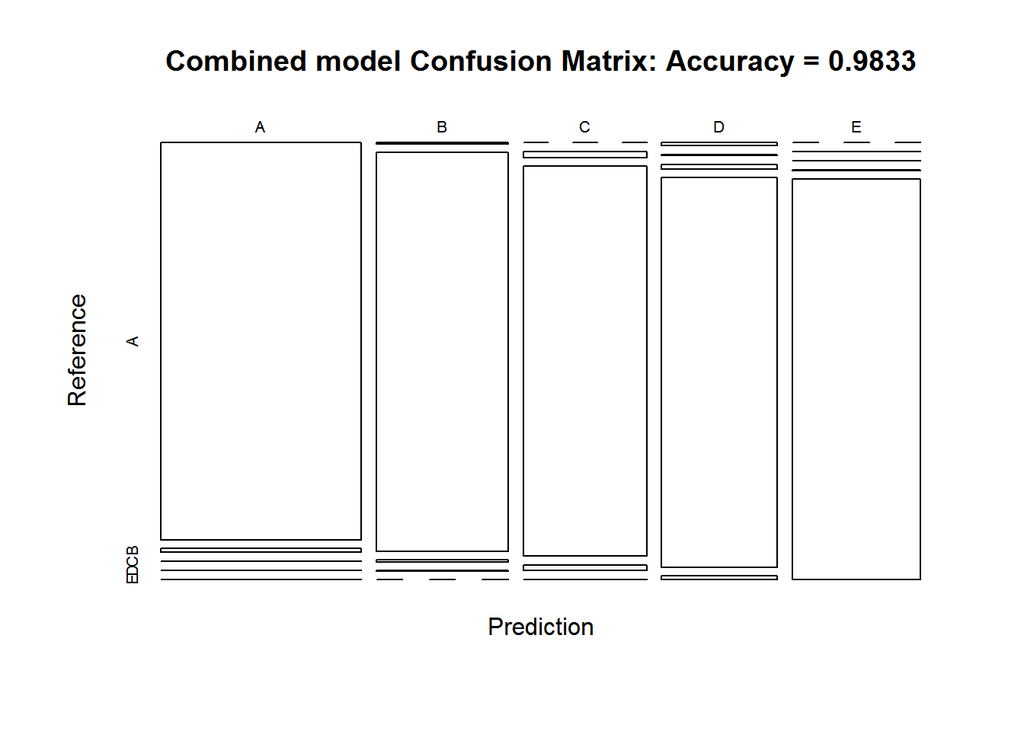

```r
plot(
        combined.confusionmatrix$table,
        col = combined.confusionmatrix$byClass,
        main = paste("Combined model Confusion Matrix: Accuracy =", round(combined.confusionmatrix$overall['Accuracy'], 4))
)
```

## As expected the predictive power of the overall model is higher than the individual model predictive power

```r
print(paste("Random forest accuracy =", round(rf.confusionmatrix$overall[1],4)))
```

```
## [1] "Random forest accuracy = 0.9504"
```

```r
print(paste("K nearest neighbour accuracy =", round(knn.confusionmatrix$overall[1],4)))
```

```
## [1] "K nearest neighbour accuracy = 0.9822"
```

```r
print(paste("Neural Net accuracy =", round(nnet.confusionmatrix$overall[1],4)))
```

```
## [1] "Neural Net accuracy = 0.9469"
```

```r
print(paste("Combined model accuracy =", round(combined.confusionmatrix$overall[1],4)))
```

```
## [1] "Combined model accuracy = 0.9833"
```

## The testing data is score using the overall model :

```r
print(paste("Predictions on testing dataset :"))
```

```
## [1] "Predictions on testing dataset :"
```

```r
combined.pred.test
```

```
##  1  2  3  4  5  6  7  8  9 10 11 12 13 14 15 16 17 18 19 20
##  B  A  A  A  A  E  D  B  A  A  B  C  B  A  E  E  A  B  B  B
## Levels: A B C D E
```